# Chap5.1-5.2

Mijeong Kim

```r
library(tsibble)
library(tsibbledata)
library(tibble)
library(dplyr)
library(knitr)
library(ggplot2)
library(fpp3)
library(fpp2)
library(seasonal)
library(feasts)
```

## 5.1 A tidy forecasting workflow

```r
library(DiagrammeR)

grViz("
  digraph {

    # Define node styles
    node [shape = plaintext, fontsize = 14]

    # Define nodes and edges
    rankdir=LR;

    Tidy -> Visualise
    Visualise -> Specify
    Specify -> Estimate
    Estimate -> Evaluate
    Evaluate -> Visualise
    Estimate -> Forecast
  }
")
```

[interactive chart not shown]

### Data preparation (tidy)

예측의 첫 단계는 데이터를 올바른 형식으로 준비하는 것이다. 이 과정에는 데이터 로드, 결측값 확인, 시계열 필터링, 기타 전처리 작업이 포함될 수 있다. {tsibble} 및 {tidyverse} 패키지를 활용하면 이 과정을 간소화할 수 있다.

모델마다 요구하는 데이터 조건이 다르며, 일부 모델은 시간 순서 정렬이 필요하고, 일부는 결측값이 없어야 한다. 따라서 데이터를 점검하는 과정은 필수적이며, 모델을 추정하기 전에 반드시 수행해야 한다.

이제 **시간에 따른 1인당 GDP(GDP per capita)**를 모델링하기 위해 관련 변수를 계산할 것이다.

```r
gdppc <- global_economy |>
  mutate(GDP_per_capita = GDP / Population)
```

### Plot the data (visualise)

시각화는 데이터를 이해하는 데 필수적인 단계이다. 데이터를 직접 확인하면 공통적인 패턴을 식별할 수 있으며, 이를 바탕으로 적절한 모델을 설정할 수 있다.

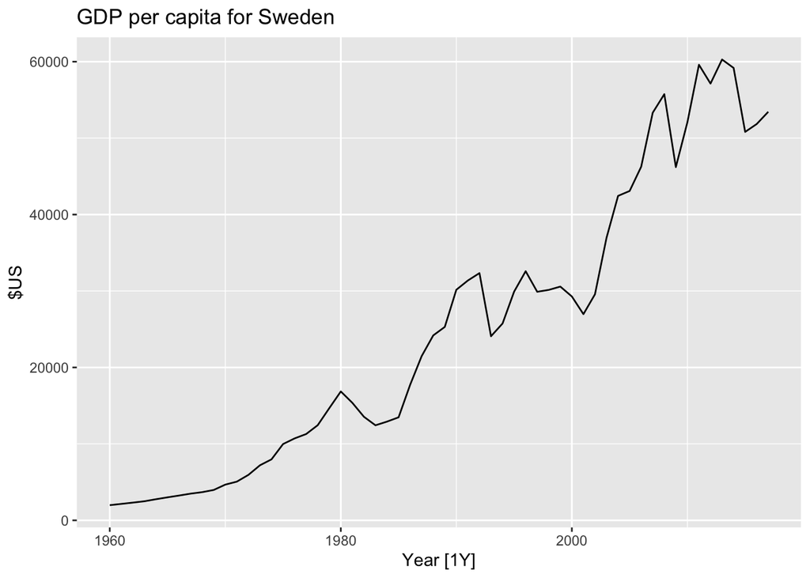

```r
gdppc |>
  filter(Country == "Sweden") |>
  autoplot(GDP_per_capita) +
  labs(y = "$US", title = "GDP per capita for Sweden")
```

### Define a model (specify)

예측에는 다양한 시계열 모델이 있으며, 적절한 모델을 선택하는 것이 중요하다.

`fable` 패키지에서는 **공식(`y ~ x`) 형태**로 모델을 지정하며, **왼쪽에는 반응 변수, 오른쪽에는 모델 구조**를 작성한다.

예를 들어, **1인당 GDP(GDP per capita)**의 **선형 추세(linear trend) 모델**을 설정하려면 다음과 같이 한다.

TSLM(GDP_per_capita ~ trend()).

이 문서에서는 `fable` 패키지에서 **시계열 모델을 지정하는 방법**을 설명한다.

이 예제에서는 **TSLM() (Time Series Linear Model)**을 사용하여 `GDP_per_capita`를 **추세(trend)** 기반으로 모델링한다.  
`trend()` 함수는 `TSLM()` 내에서 **선형 추세(linear trend)**를 지정하는 **특수 함수(special function)**이다.

### Train the model (estimate)

적절한 모델을 지정한 후에는 데이터를 사용하여 모델을 학습(train)해야 한다.

하나 이상의 모델을 model() 함수를 사용하여 추정할 수 있다.

```r
fit <- gdppc |>
  model(trend_model = TSLM(GDP_per_capita ~ trend()))
```

이 과정에서는 tsibble 내 각 키 변수 조합에 대해 선형 추세 모델을 적합(fit) 한다.

이 예제에서는 263개국 각각에 대해 모델을 적합하게 된다.

결과로 생성된 객체는 모델 테이블(model table) 또는 **“mable”**이라고 한다.

```r
fit
```

```
## # A mable: 263 x 2
## # Key:     Country [263]
##    Country             trend_model
##    <fct>                   <model>
##  1 Afghanistan              <TSLM>
##  2 Albania                  <TSLM>
##  3 Algeria                  <TSLM>
##  4 American Samoa           <TSLM>
##  5 Andorra                  <TSLM>
##  6 Angola                   <TSLM>
##  7 Antigua and Barbuda      <TSLM>
##  8 Arab World               <TSLM>
##  9 Argentina                <TSLM>
## 10 Armenia                  <TSLM>
## # ℹ 253 more rows
```

### Check model performance (evaluate)

모델이 적합된 후에는 해당 모델이 데이터에 대해 얼마나 잘 작동했는지 확인하는 것이 중요하다. 모델의 동작을 점검할 수 있는 여러 가지 진단 도구가 있으며, 한 모델을 다른 모델과 비교할 수 있는 정확도 측정 방법도 있다. 5.8절과 5.9절에서 이에 대한 자세한 내용을 다룰 것이다.

### Produce forecasts (forecast)

적절한 모델을 설정하고 추정 및 검토한 후에는 `forecast()` 함수를 사용하여 예측을 생성할 차례이다. 이 함수를 가장 쉽게 사용하는 방법은 예측할 미래 관측치의 개수를 지정하는 것이다. 예를 들어, 향후 10개의 관측치에 대한 예측을 생성하려면 `h = 10`을 사용하면 된다. 또한 자연어를 사용할 수도 있으며, 예를 들어 `h = "2 years"`를 사용하면 향후 2년간의 예측을 수행할 수 있다.

다른 상황에서는 예측할 미래 기간의 데이터셋을 제공하는 것이 더 편리할 수도 있다. 특히, 모델이 외생 변수(exogenous regressors)와 같은 추가 정보를 활용하는 경우에는 이러한 방식이 일반적으로 필요하다. 모델에 필요한 추가 데이터는 예측할 관측치의 데이터셋에 포함될 수 있다.

```r
fit |> forecast(h = "3 years")
```

```
## # A fable: 789 x 5 [1Y]
## # Key:     Country, .model [263]
##    Country        .model       Year
##    <fct>          <chr>       <dbl>
##  1 Afghanistan    trend_model  2018
##  2 Afghanistan    trend_model  2019
##  3 Afghanistan    trend_model  2020
##  4 Albania        trend_model  2018
##  5 Albania        trend_model  2019
##  6 Albania        trend_model  2020
##  7 Algeria        trend_model  2018
##  8 Algeria        trend_model  2019
##  9 Algeria        trend_model  2020
## 10 American Samoa trend_model  2018
## # ℹ 779 more rows
## # ℹ 2 more variables: GDP_per_capita <dist>, .mean <dbl>
```

이것은 예측 테이블, 즉 “fable”이다. 각 행은 각 국가에 대한 하나의 예측 기간에 해당한다. GDP_per_capita 열에는 예측 분포가 포함되어 있으며, .mean 열에는 점 예측(point forecast)이 포함되어 있다. 점 예측은 예측 분포의 평균값(혹은 기대값)이다.

예측 결과는 autoplot() 함수를 사용하여 기존 데이터와 함께 시각화할 수 있다.

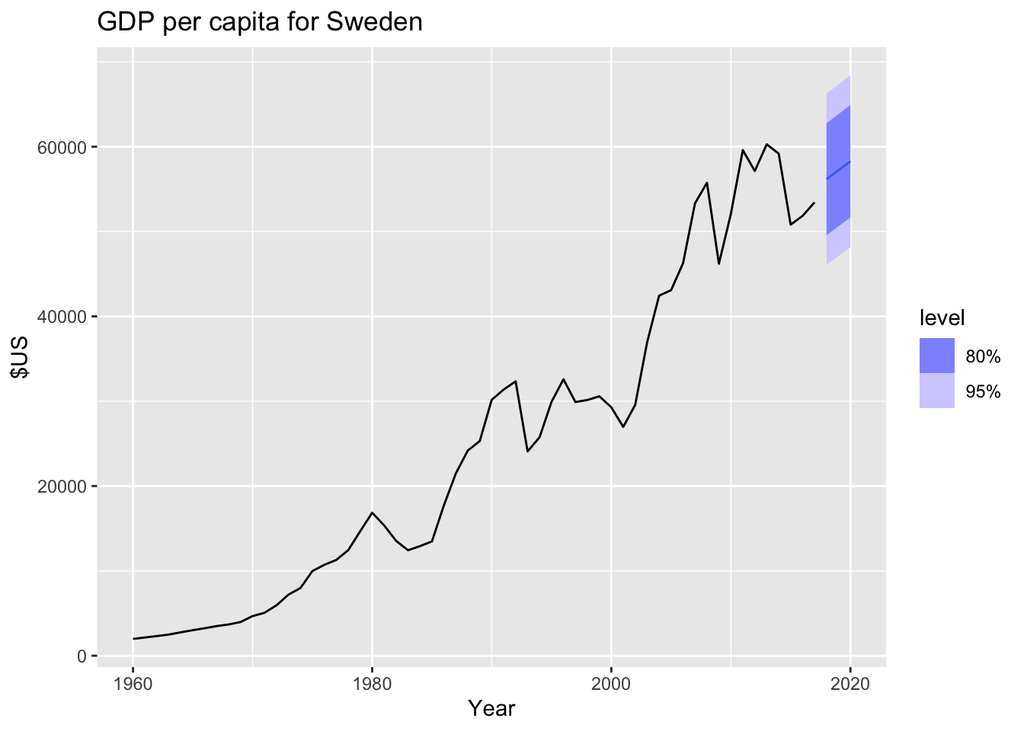

```r
fit |>
  forecast(h = "3 years") |>
  filter(Country == "Sweden") |>
  autoplot(gdppc) +
  labs(y = "$US", title = "GDP per capita for Sweden")
```

## 5.2 Some simple forecasting methods

```r
bricks <- aus_production |>
  filter_index("1970 Q1" ~ "2004 Q4") |>
  select(Bricks)
```

### Mean method

여기서 모든 미래 값의 예측은 과거 데이터의 평균(또는 “mean”)과 동일하다. 과거 데이터를 $y_1, \dots, y_T$로 나타낸다면, 예측은 다음과 같이 쓸 수 있다.
$$\hat{y}_{T+h|T} = \bar{y} = \frac{y_1 + \dots + y_T}{T}$$
여기서 $\hat{y}_{T+h|T}$ 표기는 데이터 $y_1, \dots, y_T$을 기반으로 한 $y_{T+h}$의 추정값을 의미한다.

```r
bricks |> model(MEAN(Bricks))
```

```
## # A mable: 1 x 1
##   `MEAN(Bricks)`
##          <model>
## 1         <MEAN>
```

### Naïve method

naïve 예측에서는 모든 미래 예측값을 마지막 관측값과 동일하게 설정한다. 즉,
$$\hat{y}_{T+h|T} = y_T$$
이 방법은 많은 경제 및 금융 시계열 데이터에서 놀라울 정도로 잘 작동한다.

```r
bricks |> model(NAIVE(Bricks))
```

```
## # A mable: 1 x 1
##   `NAIVE(Bricks)`
##           <model>
## 1         <NAIVE>
```

Naïve 예측은 데이터가 랜덤 워크(random walk)를 따를 때 최적의 방법이므로(9.1절 참고), 랜덤 워크 예측(random walk forecasts)이라고도 한다. NAIVE 대신 RW() 함수를 사용할 수 있다.

### Seasonal naïve method

비슷한 방법이 계절성이 강한 데이터에도 유용하다. 이 경우, 각 예측값을 동일한 계절에서 마지막으로 관측된 값과 같도록 설정한다(예: 전년도의 같은 월). 공식적으로, 시점 $T+h$의 예측값은 다음과 같이 표현된다.
$$\hat{y}_{T+h|T} = y_{T+h - m(k+1)}$$
여기서,

- $m$ = 계절 주기(seasonal period),
- $k$ = $(h-1)/m$의 정수 부분(즉, 시점 $T+h$ 이전 예측 기간 동안의 완전한 연도의 개수).

이 공식은 실제보다 복잡해 보일 수 있다. 예를 들어, 월별 데이터의 경우 모든 미래 2월 값의 예측은 마지막으로 관측된 2월 값과 같다. 분기별 데이터의 경우, 모든 미래 2분기(Q2) 값의 예측은 마지막으로 관측된 2분기 값과 동일하다(Q2는 2분기를 의미함). 다른 월, 분기 및 기타 계절 주기에도 동일한 규칙이 적용된다.

### Drift method

나이브(naïve) 방법의 변형 중 하나는 예측값이 시간에 따라 증가하거나 감소하도록 허용하는 것이다. 여기서 시간에 따른 변화량(드리프트, drift)은 과거 데이터에서 관측된 평균 변화량으로 설정된다. 따라서 시점 $T+h$의 예측값은 다음과 같이 주어진다.
$$\hat{y}_{T+h|T} = y_T + h \frac{1}{T-1} \sum_{t=2}^{T} (y_t - y_{t-1})$$
이는 다시 다음과 같이 표현할 수도 있다.
$$\hat{y}_{T+h|T} = y_T + h \left( \frac{y_T - y_1}{T-1} \right)$$
이는 첫 번째 관측값과 마지막 관측값 사이에 선을 그리고, 이를 미래로 연장하는 것과 동일한 방식이다.

```r
bricks |> model(RW(Bricks ~ drift()))
```

```
## # A mable: 1 x 1
##   `RW(Bricks ~ drift())`
##                  <model>
## 1          <RW w/ drift>
```

### Example: Australian quarterly beer production

그림 5.7은 호주 분기별 맥주 생산량(1992년~2006년)에 대해 첫 세 가지 예측 방법을 적용한 결과를 보여준다. 예측값은 이후 3.5년 동안의 실제 값과 비교되었다.

```
## Plot variable not specified, automatically selected `.vars = Beer`
```

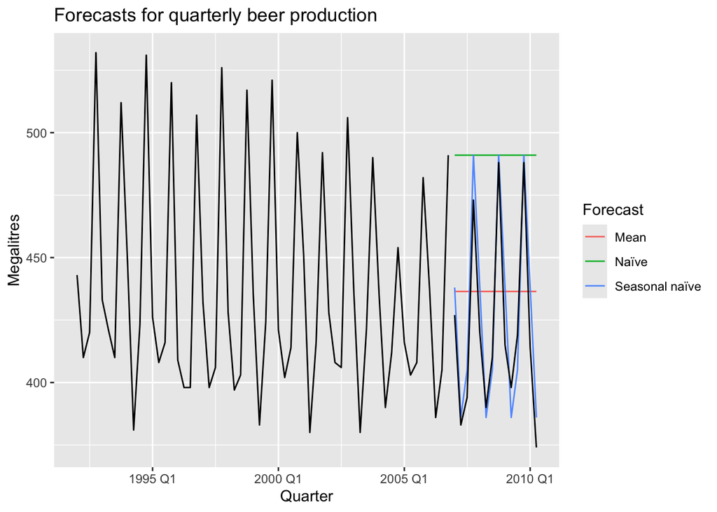

```r
# Set training data from 1992 to 2006
train <- aus_production |>
  filter_index("1992 Q1" ~ "2006 Q4")
# Fit the models
beer_fit <- train |>
  model(
    Mean = MEAN(Beer),
    `Naïve` = NAIVE(Beer),
    `Seasonal naïve` = SNAIVE(Beer)
  )
# Generate forecasts for 14 quarters
beer_fc <- beer_fit |> forecast(h = 14)
# Plot forecasts against actual values
beer_fc |>
  autoplot(train, level = NULL) +
  autolayer(
    filter_index(aus_production, "2007 Q1" ~ .),
    colour = "black"
  ) +
  labs(
    y = "Megalitres",
    title = "Forecasts for quarterly beer production"
  ) +
  guides(colour = guide_legend(title = "Forecast"))
```

이 경우, 2007년 이후의 실제 값과 가장 가까운 예측은 Seasonal Naïve 예측뿐이다.

### Example: Google’s daily closing stock price

그림 5.8에서는 비계절적(non-seasonal) 방법을 사용하여 2015년 구글의 일일 종가를 예측하고, 한 달 뒤까지의 값을 예측하였다. 주식 가격은 매일 관측되지 않기 때문에, 먼저 달력 날짜가 아닌 거래일(trading days)을 기준으로 새로운 시간 인덱스를 설정하였다.

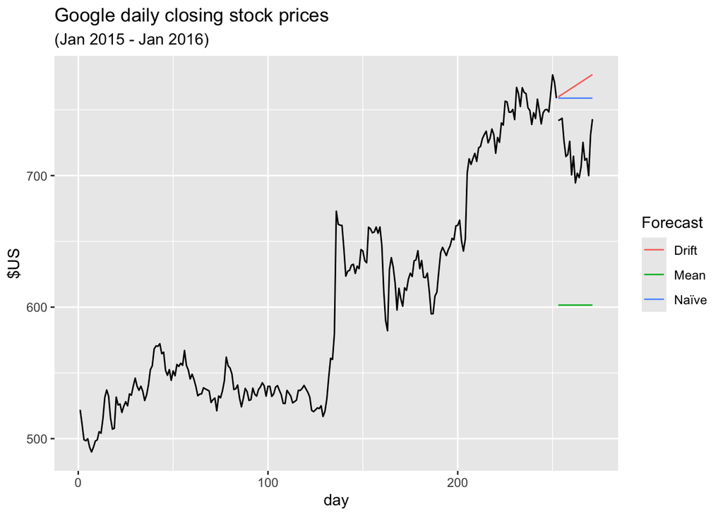

```r
# Re-index based on trading days
google_stock <- gafa_stock |>
  filter(Symbol == "GOOG", year(Date) >= 2015) |>
  mutate(day = row_number()) |>
  update_tsibble(index = day, regular = TRUE)
# Filter the year of interest
google_2015 <- google_stock |> filter(year(Date) == 2015)
# Fit the models
google_fit <- google_2015 |>
  model(
    Mean = MEAN(Close),
    `Naïve` = NAIVE(Close),
    Drift = NAIVE(Close ~ drift())
  )
# Produce forecasts for the trading days in January 2016
google_jan_2016 <- google_stock |>
  filter(yearmonth(Date) == yearmonth("2016 Jan"))
google_fc <- google_fit |>
  forecast(new_data = google_jan_2016)
# Plot the forecasts
google_fc |>
  autoplot(google_2015, level = NULL) +
  autolayer(google_jan_2016, Close, colour = "black") +
  labs(y = "$US",
       title = "Google daily closing stock prices",
       subtitle = "(Jan 2015 - Jan 2016)") +
  guides(colour = guide_legend(title = "Forecast"))
```

때때로 이러한 단순한 방법 중 하나가 가장 적절한 예측 방법이 될 수도 있다. 그러나 대부분의 경우, 이러한 방법들은 최선의 선택이라기보다 기준점(benchmark) 역할을 하게 된다. 즉, 우리가 개발하는 모든 예측 방법은 이러한 단순한 방법들과 비교하여 성능이 더 우수한지 확인해야 한다. 만약 그렇지 않다면, 새로운 방법을 고려할 가치가 없다.